# プライベートに AI を組み込む

Event: Offsite

@usabarashi

2026-11-24

## 自己紹介

- Motoki KAMIMURA
- GitHub: usabarashi
- 🧑🏻‍💻: Lean, Quint, TLA+, Alloy, Scala, Rust, TS, HCL, Nix, etc
- 🧑🏻‍💻: AI Agent Pachinko
- 🍵: サーバーラック導入で Homelab がスッキリした

## 本発表の内容

- 🙅: AI サービスの話
- 🙅: AI アルゴリズムの話
- 🙆: 生活を整理整頓する話

AI が適切に動く環境の整理整頓が要る

## AI の歴史

[figure not shown]

最近, 皆んなが言っている AI は大規模言語モデル

## LLM サービス利用遍歴

[figure not shown]

仕事で触らないサービスを試す

## 主に利用しているサービス

[figure not shown]

ChatGPT Plus

Chat + Work

料金体系の変更

[figure not shown]

Cursor Pro

X Subscription

料金体系の変更

[figure not shown]

OpenCode Go

Global Regions

個人情報の取り扱い

[figure not shown]

さくらの  
AI Engine

Japan Region

デジタル赤字

無邪気に学べる期間は終わった

個人のお財布の範囲で

## AI Google Account を用意する

- Google Account はキメ細かい権限設定ができない
- AI Google Account を 1 つ用意する
- AI Google Account へ, 参照してよいメールだけ転送する
- AI Google Account へ, 参照してよいファイルだけ共有する

転送やフィルタの設定は gmailctl で宣言的に管理する

プライベートに AI を組み込む

## AI を組み込んだシステムの重要要素

[figure not shown]

認知・判断・管理・運用のコストを減らす

※ 個人のスタイル

宣言性・再現性・冪等性

AI が状態を正しく判断できる

AI が何を操作したか, 人間が正しく判断できる

## Infrastructure as Code

```
infrastructure/
├── nix/        # ホストの構成・配備（hosts / modules / pkgs）
├── terraform/  # Cloud・SaaS の設定（プロバイダごと）
│   └── <provider>/
├── mail/       # メールフィルタ
└── apps/       # 小さな自動化
```

- 手で設定せず, コードで書く
- 宣言性: 手順ではなく「あるべき状態」を書く
- 再現性: 同じコードから, 同じ環境が何度でも作れる
- 冪等性: 何度実行しても, 結果が変わらない
- 管理対象の状態が分かる

## Application Nix module を IaC に統合する

[figure not shown]

Application の更新は flake.lock の更新として扱える

## Client 環境を Nix で宣言的に管理する

[figure not shown]

パッケージ・dotfiles・macOS の設定を 1 リポジトリで管理する

## 異常検知の構成

[figure not shown]

ログは Cloud Infra の可用性を活用する

## AI Agent による調査・修正の構成

[figure not shown]

参照元と更新結果が実態を表す

人が Review して Merge → TFC が自動 apply / NixOS は deploy-rs で手動

## 情報と実態の乖離を常に是正する

[figure not shown]

- 情報の正しさを常に担保する
- NixOS: 毎日 narHash を GitHub と比べ, kernel / initrd のずれも見る
- Terraform: 毎日 plan を回し, drift を見る
- 通知条件を満たしたときだけ Slack に流す

## 独自 Provider で On-Premises 機器を管理

[figure not shown]

- API がない機器は, 独自の provider で宣言的に管理する
- 通信が HTML form, REST, Bluetooth, Infrared でも, Terraform の provider プロトコルに抽象化する
- 宣言性・再現性・冪等性を確保する環境を, AI を使って作る

情報の整理

構造で把握する

ゴミ漁りにコストを払わない

## Architecture

- AI の生成物が増えると, 人間は詳細を追いきれなくなる
- 構造と動線を拠り所にして妥当性を判断する
- 片付いた家は, 置き場所が決まっている
- デジタルに質量はないが, 整理されていなければ実態はゴミ屋敷
- 情報が分類されていると, 捨てる判断ができる
- 歪さは構造から読み取る
- アーキテクチャなど専門用語があるが, 要は整理整頓

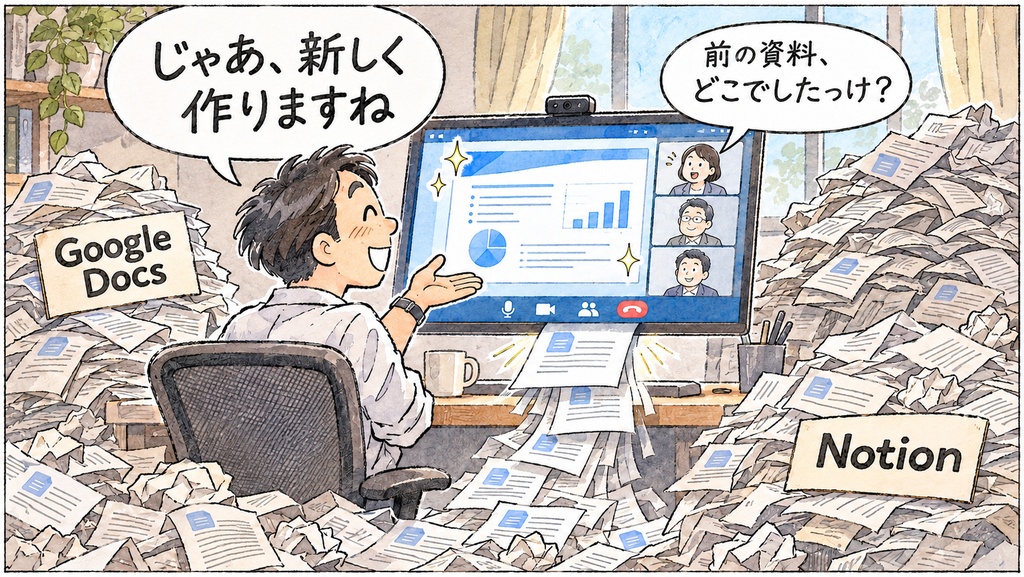

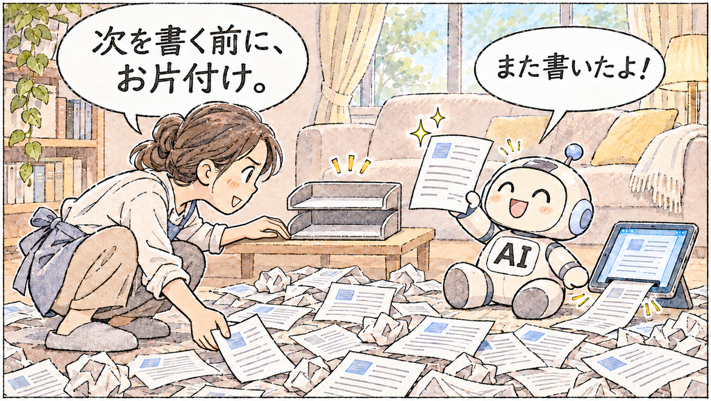

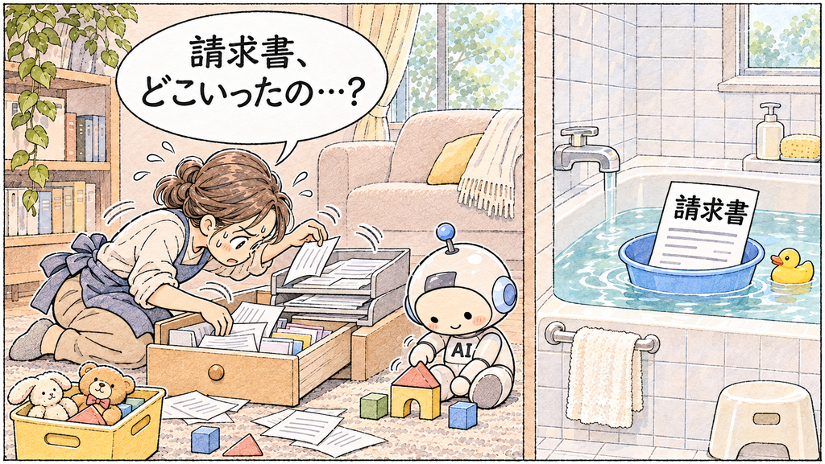

## モデルは記憶しない

[figure not shown]

使い続けるほどにフットプリントが膨張する

整理されていない情報のゴミ漁りを, 毎回トークンと待ち時間で払う

権限の管理

人間が把握していないゴミを作らせない

生活をゴミ屋敷にさせない

## Harness / Software Factory

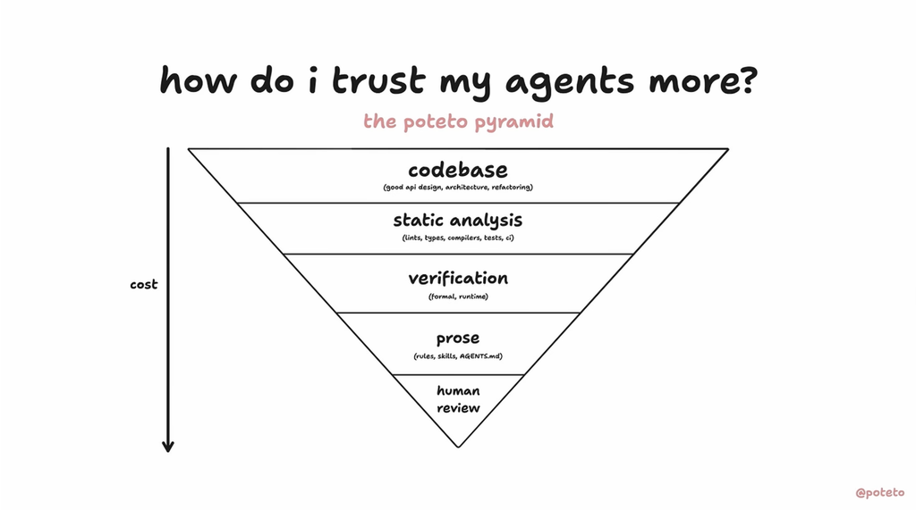

出典: All Code Is Slop (Except Mine) — Lauren Tan, SpaceXSI（ YouTube ）

https://www.youtube.com/watch?v=O_zcc6Xl12g

## Harness / Software Factory（要点）

まずはコードベースの改善 (Linterによる防止, アンチパターンの排除) と強力な検証の仕組みを整えること. 自身のコーディング環境が Slop を生み出している状態で自動化を進めれば Slop が増えるだけである.

- Agent が正しく動作すると確信できるように Agent の環境に投資する
- ループが Slop を生むなら, 自動化しても Slop が増えるだけ
  - AI は正しくないことを正当化するコメントを書き残す
  - 悪い見本を放置すると AI が模倣し, 瞬く間に全体が Slop 化する
- Agent の行動を制限しデフォルトで正しいことを行うように強制する
  - 強制力のないコメントではなく決定論的なチェックに注力する
  - 型システム, Linter, 依存グラフの制限, API設計, 実行時検証 (Chrome DevTools), 形式検証 (TLA+, Lean) を活用する

## Client Agent 構成

[figure not shown]

Client Agent 構成を Nix で宣言的に管理する

理想は, Client 環境ではなく Remote sandbox 環境で動かす

## On-Premises Remote Agent 構成

[figure not shown]

Remote Agent 構成を Nix で管理する

理想は, On-Pemisses LAN から切り離した Cloud sandbox 環境で動かす

完全に個人情報から隔離できれば Free Model を試用できる

## Security Review の構成

[figure not shown]

決定的な静的解析と, AI Agent の確率的な解析の組み合わせ

静的な側は再現でき, AI 側だけモデルとプロンプトに依存する

AI Agent には必要最低限の権限のみ個別に与える

AI

システムのコントロールブレインにしない

電気・ガス・水道と同じ位置づけにする

差し替えられる位置づけにする

## AI 組み込みは Outcome ではない

[figure not shown]

出典: Naoya Ito「問題から目を背けず取り組む — 一休の開発チームが 6 年間で学んだこと」 Speaker Deck, slide 30

[speakerdeck.com/naoya/…?slide=30](https://speakerdeck.com/naoya/wen-ti-karamu-wobei-kezuqu-rizu-mu-xiu-falsekai-fa-timuga6nian-jian-dexue-ndakoto?slide=30)

既存システムを修正しない足し算は, 臭いものに蓋をするマトリョーシカにしかならない

安全圏の足し算は水遊びでしかない

## Workflow

[figure not shown]

- ワークフロー全体を Prompt の泥団子で構成しない
- ワークフローを分解して一部の関数を AI で処理する
- 独立した関数を独立して改善してイテレーションを回す
- 個々の関数の複雑さにあわせてコスト最適化する

## Personal AI Agent

[figure not shown]

dots

OpenAI

[figure not shown]

Grok Bot

X

[figure not shown]

Muse

Meta

- 新しいパラダイムを体験するために積極的に触ってみると良い
- ブラックボックスで, 移行が保証されず, 継続性がない
- インフラとして, 認知・判断・管理・運用のコストで判断する
- 安全圏の水遊びと位置づけ, 全てを切り捨てる事を想定して採用する
- OpenClaw, Hermes Agent の導入を検討する

## Local LLM

[figure not shown]

- 非常用バッテリーや非常食などと同じ位置づけ
- 常駐させず, 使うときだけ起動する
- 高性能 GPU を購入・運用しても個人利用では採算が取れない
- 平時は Cloud-hosted LLM を使用するのがコストが安い

## まとめ

- 生活インフラの運用コストと代替手段を整理整頓する
- 1ヶ月後にはぜんぜん違うこと言ってるかも知らんけど
- nix-config
- [usabarashi blog](https://usabarashi.github.io/blog/)
- [note](https://note.com/motoki_kamimura)

## お財布に余裕がある方はご自由に

[figure not shown]

出典: @YuYoshimuta の X 投稿

x.com/YuYoshimuta/status/2119340884319945053